# Copy_of_M505_Project

**1.0 Employee Attrition Factors and Prediction**

Objective: In partial fulfilment of the requirement for AI and Application course, the project aims to determine the factors affecting employee attrition and to create a prediction model to highlight employee who are going to exit.

This is a crucial step because the employee attrition rate helps to understand the progress level of an organization. The high attrition rate shows that the employees are frequently leaving. Therefore, it is very imperative for any HR organisation to determine beforehand whether certain employee are at risk of leaving and take action.

**1.1 Business Questions To Address:**

1. What are the Top five factors that determines an employee attrition?
2. Highlight the top three roles facing attrition
3. What should the organisation do to prevent attrition?
4. Are employee with less than 3 years work experience likely to leave?
5. Is the length of time with CUrrent manager a factor in deciding attrition?

**2.0 Enviromment Preparation**

```python
#Mount the drive to google drive to backup the data
from google.colab import drive
drive.mount('/content/drive')
```

```python
##We will use interpretPL library which is not installed with Python, so this is to install the library
!pip install interpret
```

```python
#Also,  CVAE library and rulefit which will be used later in model assessment, is installed
!pip install cvae --no-deps

!pip install rulefit
```

```python
###Loading the required libraries

import pandas as pd
import numpy as np
import matplotlib.pyplot as plt
from sklearn.pipeline import make_pipeline
from sklearn.preprocessing import PolynomialFeatures, StandardScaler
from sklearn.preprocessing import OneHotEncoder
from sklearn.model_selection import train_test_split
from sklearn import metrics, linear_model, tree, naive_bayes, neighbors, ensemble, svm, manifold, inspection
from sklearn import decomposition
from rulefit import RuleFit
import statsmodels.api as sm
from interpret.glassbox import ExplainableBoostingClassifier
from interpret import show
from interpret.perf import ROC
import seaborn as sns
from cvae import cvae
import six
import sys
sys.modules['sklearn.externals.six'] = six
from skrules import SkopeRules
from sklearn import svm
from sklearn.neural_network import MLPClassifier
import math
from sklearn.ensemble import RandomForestClassifier
```

**2.1 Data Preparation**

Data Source: https://www.kaggle.com/datasets/thedevastator/employee-attrition-and-factors

```python
#Loading the dataset
hr_data = pd.read_csv('/content/drive/MyDrive/content/HR_Analytics.csv.csv')

hr_data.info()
print('The dataset is :', hr_data.shape)
```

```
<class 'pandas.core.frame.DataFrame'>
RangeIndex: 1470 entries, 0 to 1469
Data columns (total 35 columns):
 #   Column                    Non-Null Count  Dtype
---  ------                    --------------  -----
 0   Age                       1470 non-null   int64
 1   Attrition                 1470 non-null   object
 2   BusinessTravel            1470 non-null   object
 3   DailyRate                 1470 non-null   int64
 4   Department                1470 non-null   object
 5   DistanceFromHome          1470 non-null   int64
 6   Education                 1470 non-null   int64
 7   EducationField            1470 non-null   object
 8   EmployeeCount             1470 non-null   int64
 9   EmployeeNumber            1470 non-null   int64
```

[output cut: 28 more lines]

Checking the dataset for missing values

```python
hr_data.isna().sum()
```

```
Age                         0
Attrition                   0
BusinessTravel              0
DailyRate                   0
Department                  0
DistanceFromHome            0
Education                   0
EducationField              0
EmployeeCount               0
EmployeeNumber              0
EnvironmentSatisfaction     0
Gender                      0
HourlyRate                  0
JobInvolvement              0
JobLevel                    0
JobRole                     0
JobSatisfaction             0
MaritalStatus               0
MonthlyIncome               0
MonthlyRate                 0
NumCompaniesWorked          0
Over18                      0
OverTime                    0
PercentSalaryHike           0
PerformanceRating           0
RelationshipSatisfaction    0
StandardHours               0
StockOptionLevel            0
TotalWorkingYears           0
TrainingTimesLastYear       0
WorkLifeBalance             0
YearsAtCompany              0
YearsInCurrentRole          0
YearsSinceLastPromotion     0
YearsWithCurrManager        0
dtype: int64
```

From above checks, there is no missing value in the dataset. Hence, we can proceed with other aspects of the data preparation.

```python
hr_data.head()
```

|  | Age | Attrition | BusinessTravel | DailyRate | Department | DistanceFromHome | Education | EducationField | EmployeeCount | EmployeeNumber | ... | RelationshipSatisfaction | StandardHours | StockOptionLevel | TotalWorkingYears | TrainingTimesLastYear | WorkLifeBalance | YearsAtCompany | YearsInCurrentRole | YearsSinceLastPromotion | YearsWithCurrManager |
| --- | --- | --- | --- | --- | --- | --- | --- | --- | --- | --- | --- | --- | --- | --- | --- | --- | --- | --- | --- | --- | --- |
| 0 | 41 | Yes | Travel_Rarely | 1102 | Sales | 1 | 2 | Life Sciences | 1 | 1 | ... | 1 | 80 | 0 | 8 | 0 | 1 | 6 | 4 | 0 | 5 |
| 1 | 49 | No | Travel_Frequently | 279 | Research & Development | 8 | 1 | Life Sciences | 1 | 2 | ... | 4 | 80 | 1 | 10 | 3 | 3 | 10 | 7 | 1 | 7 |
| 2 | 37 | Yes | Travel_Rarely | 1373 | Research & Development | 2 | 2 | Other | 1 | 4 | ... | 2 | 80 | 0 | 7 | 3 | 3 | 0 | 0 | 0 | 0 |
| 3 | 33 | No | Travel_Frequently | 1392 | Research & Development | 3 | 4 | Life Sciences | 1 | 5 | ... | 3 | 80 | 0 | 8 | 3 | 3 | 8 | 7 | 3 | 0 |
| 4 | 27 | No | Travel_Rarely | 591 | Research & Development | 2 | 1 | Medical | 1 | 7 | ... | 4 | 80 | 1 | 6 | 3 | 3 | 2 | 2 | 2 | 2 |

5 rows × 35 columns

**2.1.1 Data Preparation for Modelling:**  
There are a number of columns with categorical data type. For us to use the data for modeling, we have to covert them into numerical vlaue using one-hot encoding which is available in sklearn package.

```
array([[<Axes: title={'center': 'Age'}>,
        <Axes: title={'center': 'DailyRate'}>,
        <Axes: title={'center': 'DistanceFromHome'}>,
        <Axes: title={'center': 'Education'}>,
        <Axes: title={'center': 'EmployeeCount'}>],
       [<Axes: title={'center': 'EmployeeNumber'}>,
        <Axes: title={'center': 'EnvironmentSatisfaction'}>,
        <Axes: title={'center': 'HourlyRate'}>,
        <Axes: title={'center': 'JobInvolvement'}>,
        <Axes: title={'center': 'JobLevel'}>],
       [<Axes: title={'center': 'JobSatisfaction'}>,
        <Axes: title={'center': 'MonthlyIncome'}>,
        <Axes: title={'center': 'MonthlyRate'}>,
        <Axes: title={'center': 'NumCompaniesWorked'}>,
        <Axes: title={'center': 'PercentSalaryHike'}>],
       [<Axes: title={'center': 'PerformanceRating'}>,
        <Axes: title={'center': 'RelationshipSatisfaction'}>,
        <Axes: title={'center': 'StandardHours'}>,
        <Axes: title={'center': 'StockOptionLevel'}>,
        <Axes: title={'center': 'TotalWorkingYears'}>],
       [<Axes: title={'center': 'TrainingTimesLastYear'}>,
        <Axes: title={'center': 'WorkLifeBalance'}>,
        <Axes: title={'center': 'YearsAtCompany'}>,
        <Axes: title={'center': 'YearsInCurrentRole'}>,
        <Axes: title={'center': 'YearsSinceLastPromotion'}>],
       [<Axes: title={'center': 'YearsWithCurrManager'}>, <Axes: >,
        <Axes: >, <Axes: >, <Axes: >]], dtype=object)
```

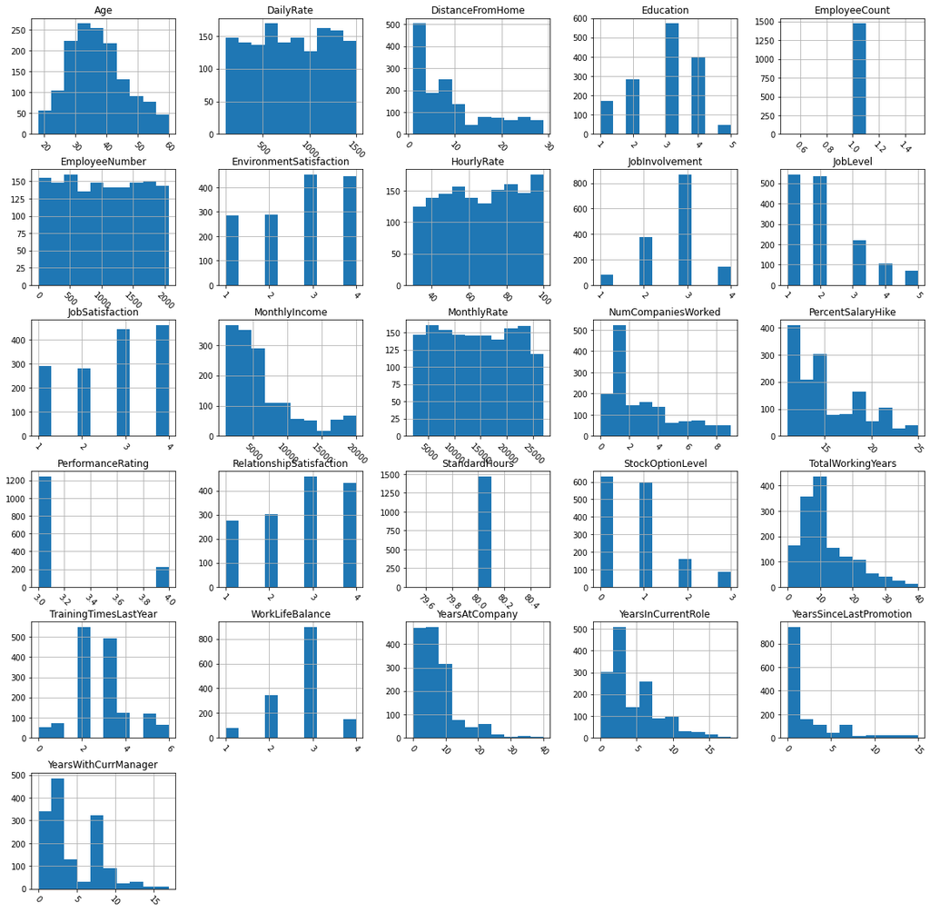

```python
#Exploring the distribution of data per column

hr_data.hist(figsize=(20,20), xrot=-45)
```

As we can see from the above distribution and by intuition, some of the features are not relevant to the Employee attrition and we can remove them. For example, **EmployeeCount, StandardHours, EmployeeNumber and Over18**.

```
<function matplotlib.pyplot.show(close=None, block=None)>
```

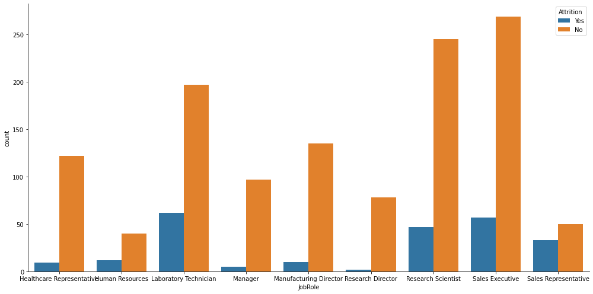

```python
#Checking Attrition count by job role
sns.catplot(x='JobRole', hue='Attrition', data=hr_data, kind="count", height=7, aspect=2, legend=False)
plt.legend(loc='upper right', title='Attrition')
plt.tight_layout()
plt.show
```

```
<function matplotlib.pyplot.show(close=None, block=None)>
```

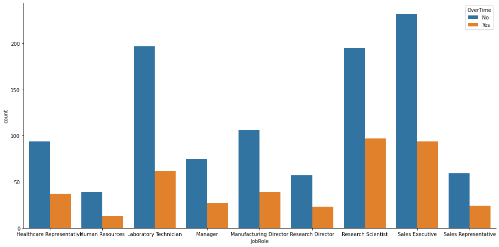

```python
#Checking impact of overtime on the Job Role
sns.catplot(x='JobRole', hue='OverTime', data=hr_data, kind="count", height=7, aspect=2, legend=False)
plt.legend(loc='upper right', title='OverTime')
plt.tight_layout()
plt.show
```

```python
#Removing the irrelevant data
hr_data.drop('Over18', axis=1, inplace=True)
hr_data.drop('EmployeeCount', axis=1, inplace=True)
hr_data.drop('StandardHours', axis=1, inplace=True)
hr_data.drop('EmployeeNumber', axis=1, inplace=True)
```

Next we will convert the non-numerical variables to numerical so that the data can be ready for modeling. Though, there are a number of ways to achieve this, One-hot encoding package from skitlearn will be employed.

```python
# Converting object type of columns to category
hr_data['BusinessTravel']=hr_data['BusinessTravel'].astype('category')
hr_data['Department']=hr_data['Department'].astype('category')
hr_data['EducationField']=hr_data['EducationField'].astype('category')
hr_data['JobRole']=hr_data['JobRole'].astype('category')
hr_data['MaritalStatus']=hr_data['MaritalStatus'].astype('category')
hr_data['OverTime']=hr_data['OverTime'].astype('category')
hr_data['Gender']=hr_data['Gender'].astype('category')


#Save the categorical label into a list and put label for each encoded cloumn
cat_cols = ["BusinessTravel", "Department","EducationField","JobRole","MaritalStatus","OverTime","Gender"]
cat_cols_encoded = []
for col in cat_cols:
  cat_cols_encoded += [f"{col[0]}_{cat}" for cat in list(hr_data[col].unique())]

cat_cols_encoded

#Create an instance of One-hot-encoder
enc=OneHotEncoder()

#Passing encoded columns
enc_data=pd.DataFrame(enc.fit_transform(hr_data[cat_cols]).toarray(),columns=cat_cols_encoded)

#Merge encoded columns with main data
hrdata_enc=hr_data.join(enc_data)

hrdata_enc.head()
```

|  | Age | Attrition | BusinessTravel | DailyRate | Department | DistanceFromHome | Education | EducationField | EnvironmentSatisfaction | Gender | ... | J_Sales Representative | J_Research Director | J_Human Resources | M_Single | M_Married | M_Divorced | O_Yes | O_No | G_Female | G_Male |
| --- | --- | --- | --- | --- | --- | --- | --- | --- | --- | --- | --- | --- | --- | --- | --- | --- | --- | --- | --- | --- | --- |
| 0 | 41 | Yes | Travel_Rarely | 1102 | Sales | 1 | 2 | Life Sciences | 2 | Female | ... | 0.0 | 1.0 | 0.0 | 0.0 | 0.0 | 1.0 | 0.0 | 1.0 | 1.0 | 0.0 |
| 1 | 49 | No | Travel_Frequently | 279 | Research & Development | 8 | 1 | Life Sciences | 3 | Male | ... | 1.0 | 0.0 | 0.0 | 0.0 | 1.0 | 0.0 | 1.0 | 0.0 | 0.0 | 1.0 |
| 2 | 37 | Yes | Travel_Rarely | 1373 | Research & Development | 2 | 2 | Other | 4 | Male | ... | 0.0 | 0.0 | 0.0 | 0.0 | 0.0 | 1.0 | 0.0 | 1.0 | 0.0 | 1.0 |
| 3 | 33 | No | Travel_Frequently | 1392 | Research & Development | 3 | 4 | Life Sciences | 4 | Female | ... | 1.0 | 0.0 | 0.0 | 0.0 | 1.0 | 0.0 | 0.0 | 1.0 | 1.0 | 0.0 |
| 4 | 27 | No | Travel_Rarely | 591 | Research & Development | 2 | 1 | Medical | 1 | Male | ... | 0.0 | 0.0 | 0.0 | 0.0 | 1.0 | 0.0 | 1.0 | 0.0 | 0.0 | 1.0 |

5 rows × 59 columns

```python
#Our target variable Attrition, is still a binary categorical variable, we will convert it to numerical values (0 or 1)
hrdata_enc['Attrition'] = np.where(hrdata_enc["Attrition"] == 'Yes', 1, 0)
hrdata_enc['Attrition'] = hrdata_enc['Attrition'].astype(str).astype(int)
```

```python
hrdata_enc.drop(['BusinessTravel', 'Department', 'EducationField', 'Gender', 'JobRole', 'MaritalStatus', 'OverTime'], axis = 1, inplace = True)

hrdata_enc.info()
hrdata_enc.shape
```

```
<class 'pandas.core.frame.DataFrame'>
RangeIndex: 1470 entries, 0 to 1469
Data columns (total 52 columns):
 #   Column                       Non-Null Count  Dtype
---  ------                       --------------  -----
 0   Age                          1470 non-null   int64
 1   Attrition                    1470 non-null   int64
 2   DailyRate                    1470 non-null   int64
 3   DistanceFromHome             1470 non-null   int64
 4   Education                    1470 non-null   int64
 5   EnvironmentSatisfaction      1470 non-null   int64
 6   HourlyRate                   1470 non-null   int64
 7   JobInvolvement               1470 non-null   int64
 8   JobLevel                     1470 non-null   int64
 9   JobSatisfaction              1470 non-null   int64
```

[output cut: 44 more lines]

```
(1470, 52)
```

We also need to confirm if the target variable is imbalanced to prevent bias in the prediction.

```python
hrdata_enc['Attrition'].value_counts()
```

```
0    1233
1     237
Name: Attrition, dtype: int64
```

We have to implement a balancing technique to smoothen the data.

```python
#We will use the resample package to up sample the minority class
from sklearn.utils import resample

#first we separate the majority and minority class
hrdata_enc_maj = hrdata_enc[hrdata_enc.Attrition==0]
hrdata_enc_min = hrdata_enc[hrdata_enc.Attrition==1]

# Upsample minority class
hr_minority_upsampled = resample(hrdata_enc_min,
                                 replace=True,     # sample with replacement
                                 n_samples=1233,    # to match majority class
                                 random_state=123) # reproducible results

# Combine majority class with upsampled minority class
hrdata_upsampled = pd.concat([hrdata_enc_maj, hr_minority_upsampled])

# Display new class counts
hrdata_upsampled.Attrition.value_counts()
```

```
0    1233
1    1233
Name: Attrition, dtype: int64
```

From above, we can see the updampled DataFrame has more observations than the original, and the ratio of the two classes is now 1:1. We will reserve this for model in later session. But now we will also resample by down sampling the majority class and we compare the performance later.

```python
# Downsample minority class
hr_majority_down_sampled = resample(hrdata_enc_maj,
                                 replace=True,     # sample with replacement
                                 n_samples=237,    # to match minority class
                                 random_state=123) # reproducible results

# Combine minority class with down sampled majority class
hrdata_downsampled = pd.concat([hrdata_enc_min, hr_majority_down_sampled])

# Display new class counts
hrdata_downsampled.Attrition.value_counts()
```

```
1    237
0    237
Name: Attrition, dtype: int64
```

Next step is the splitting of the new datasets(upsampled, downsampled) into training and testing set. We will only reserve 25% of the data for testing and 75% for the training.

```python
#Separating the upsample data into features(x_up) and the target variables(y_up)
x_up = hrdata_upsampled.drop('Attrition', axis=1).copy()
y_up = hrdata_upsampled['Attrition'].copy()
print(x_up.shape)
print(y_up.shape)
```

```
(2466, 51)
(2466,)
```

We need to apply scaling to make the data of same class.

```python
sc = StandardScaler()
x_up.columns = x_up.columns.astype(str)
x_up_sc = sc.fit_transform(x_up)
```

We split the features and target variables into train and test set

```python
rand = 123
x_up_sc_train, x_up_sc_test, y_up_train, y_up_test = train_test_split(x_up_sc, y_up, test_size = 0.25)
```

**3.0 Data Modeling**

**3.1.0 Data Modeling using the Up-Sample**

For this project, we will use the concept of nested dictionary to create each instance of the model and store it in the global dictionary object for use in the prediction later.

```python
#A dictionary object is created to hold the various regression model instance
Att_class_mod={
#Generalized Linear Models
 'logistic':{'model': linear_model.LogisticRegression()},
 'ridge':{'model': linear_model. RidgeClassifierCV(cv=5, alphas=[1e-3, 1e-2,1e-1, 1], class_weight='balanced')},
 #Tree Algorithm
 'decision_tree':{'model': tree.DecisionTreeClassifier(max_depth=7, random_state=rand)},
 #Nearest Neighbors
 'knn':{'model': neighbors.KNeighborsClassifier(n_neighbors=7)},
 #Naive Bayes
 'naive_bayes':{'model': naive_bayes.GaussianNB()},
 #Ensemble Methods
 'gradient_boosting':{'model':ensemble.GradientBoostingClassifier(n_estimators=210)},
 'random_forest':{'model':ensemble.RandomForestClassifier(max_depth=11,class_weight='balanced', random_state=rand)},
 #Neural Networks
 'mlp':{'model': make_pipeline(StandardScaler(), MLPClassifier(hidden_layer_sizes=(7,), max_iter=500, early_stopping=True, random_state=rand))}
 }
```

Next is the fitting of the model. We iterate through the dictionary object of models created earier, fit them to the training data, and predict and compute two metrics based on the quality of these predictions.

```python
#iterating through each model to fit the data. Only ridge model does not predict probabilities, hence it's fitted differently
for model_name in Att_class_mod.keys():
 fitted_model = Att_class_mod[model_name]['model'].fit(x_up_sc_train, y_up_train)
 y_train_pred = fitted_model.predict(x_up_sc_train)
 if model_name == 'ridge':
  y_test_pred = fitted_model.predict(x_up_sc_test)
 else:
  y_test_prob = fitted_model.predict_proba(x_up_sc_test)[:,1]
  y_test_pred = np.where(y_test_prob > 0.5, 1, 0)
 Att_class_mod[model_name]['fitted'] = fitted_model
 Att_class_mod[model_name]['probs'] = y_test_prob
 Att_class_mod[model_name]['preds'] = y_test_pred
 Att_class_mod[model_name]['Accuracy_train'] = metrics.accuracy_score(y_up_train, y_train_pred)
 Att_class_mod[model_name]['Accuracy_test'] = metrics.accuracy_score(y_up_test, y_test_pred)
 Att_class_mod[model_name]['Recall_train'] = metrics.recall_score(y_up_train, y_train_pred)
 Att_class_mod[model_name]['Recall_test'] = metrics.recall_score(y_up_test, y_test_pred)
 if model_name != 'ridge':
  Att_class_mod[model_name]['ROC_AUC_test'] = metrics.roc_auc_score(y_up_test, y_test_prob)
 else:
  Att_class_mod[model_name]['ROC_AUC_test'] = 0
 Att_class_mod[model_name]['F1_test'] = metrics.f1_score(y_up_test, y_test_pred)
 Att_class_mod[model_name]['MCC_test'] = metrics.matthews_corrcoef(y_up_test, y_test_pred)
```

```python
# To check the metrics, we convert the dictionary to a DataFrame and display the metrics in a sorted and color-coded fashion

Att_class_metrics = pd.DataFrame.from_dict(Att_class_mod, 'index')[['Accuracy_train', 'Accuracy_test', 'Recall_train', 'Recall_test', 'ROC_AUC_test', 'F1_test', 'MCC_test']]
Att_class_metrics.sort_values(by='ROC_AUC_test', ascending=False).\
 style.background_gradient(cmap='plasma', low=0.3, high=1,\
 subset=['Accuracy_train', 'Accuracy_test']).\
 background_gradient(cmap='viridis', low=1, high=0.3,\
 subset=['Recall_train', 'Recall_test',\
 'ROC_AUC_test', 'F1_test', 'MCC_test'])
```

|  | Accuracy_train | Accuracy_test | Recall_train | Recall_test | ROC_AUC_test | F1_test | MCC_test |
| --- | --- | --- | --- | --- | --- | --- | --- |
| random_forest | 0.998918 | 0.965964 | 0.997797 | 0.978462 | 0.995269 | 0.968037 | 0.931892 |
| gradient_boosting | 0.989724 | 0.946515 | 0.991189 | 0.972308 | 0.979220 | 0.950376 | 0.893512 |
| decision_tree | 0.885884 | 0.846029 | 0.890969 | 0.886154 | 0.885938 | 0.858420 | 0.691669 |
| mlp | 0.798269 | 0.808752 | 0.819383 | 0.821538 | 0.880753 | 0.819018 | 0.616286 |
| knn | 0.865333 | 0.805511 | 0.931718 | 0.880000 | 0.874410 | 0.826590 | 0.612860 |
| logistic | 0.778799 | 0.773096 | 0.780837 | 0.763077 | 0.862645 | 0.779874 | 0.546558 |
| naive_bayes | 0.672255 | 0.692058 | 0.764317 | 0.806154 | 0.793656 | 0.733894 | 0.383994 |
| ridge | 0.775554 | 0.784441 | 0.792952 | 0.790769 | 0.000000 | 0.794436 | 0.567897 |

The above table of the dataframe shows the tree-based model as the best performing model(random forest, gradient boosting and decision tree). We will use these three models to determine the feature importance in the later section.

To visualise the ROC_AUC metrics, we plot it for the worst performing model naive_bayes(in terms of ROC_AUC metric) below:

[figure not shown]

```python
plt.tick_params(axis = 'both', which = 'major',\
 labelsize = 12)
fpr, tpr, _ = metrics.roc_curve(y_up_test,
 Att_class_mod['naive_bayes']['probs'])
plt.plot(fpr, tpr, label='ROC curve (area = %0.2f)' %\
 Att_class_mod['naive_bayes']['ROC_AUC_test'])
plt.plot([0, 1], [0, 1])
plt.xlabel('False Positive Rate', fontsize = 14)
plt.ylabel('True Positive Rate', fontsize = 14)
plt.xlim([0.0, 1.0])
plt.ylim([0.0, 1.0])
plt.legend(loc="lower right")
```

To visualise the ROC_AUC metrics, we plot it for the best performing model random_forest(in terms of ROC_AUC metric) below:

[figure not shown]

```python
plt.tick_params(axis = 'both', which = 'major',\
 labelsize = 12)
fpr, tpr, _ = metrics.roc_curve(y_up_test,
 Att_class_mod['random_forest']['probs'])
plt.plot(fpr, tpr, label='ROC curve (area = %0.2f)' %\
 Att_class_mod['random_forest']['ROC_AUC_test'])
plt.plot([0, 1], [0, 1])
plt.xlabel('False Positive Rate', fontsize = 14)
plt.ylabel('True Positive Rate', fontsize = 14)
plt.xlim([0.0, 1.0])
plt.ylim([0.0, 1.0])
plt.legend(loc="lower right")
```

**Interpretations of the Metric Scores generated by the Classification models above**: As we can we, Random Forest performed best for all the metrics, and the Accuracy on test set is not much far from the training set, which suggests the overfitting is minimal. We would apply some parameter tuning to see if it improves the metric on the test.

**3.1.1 Data Modeling Using the Down-sample.**

```python
#Separating the down sample data into features(x_down) and the target variables(y_down)
x_down = hrdata_downsampled.drop('Attrition', axis=1).copy()
y_down = hrdata_downsampled['Attrition'].copy()
print(x_down.shape)
print(y_down.shape)
```

```
(474, 51)
(474,)
```

```python
#create an instance of Standard scaler and use it to scale the down_sample
sc = StandardScaler()
x_down.columns = x_down.columns.astype(str)
x_down_sc = sc.fit_transform(x_down)
```

Next the down_sample scaled data is split into train and test set using 15% of the sample as test because of the total size.

```python
rand = 123
x_down_sc_train, x_down_sc_test, y_down_train, y_down_test = train_test_split(x_down_sc, y_down, test_size = 0.15)
```

We create another dictionary of the various classification models to and use it to fit the down_sample data.

```python
#A dictionary object is created to hold the various model instance
Att_class_mod2={
#Generalized Linear Models
 'logistic':{'model': linear_model.LogisticRegression()},
 'ridge':{'model': linear_model. RidgeClassifierCV(cv=5, alphas=[1e-3, 1e-2,1e-1, 1], class_weight='balanced')},
 #Tree Algorithm
 'decision_tree':{'model': tree.DecisionTreeClassifier(max_depth=7, random_state=rand)},
 #Nearest Neighbors
 'knn':{'model': neighbors.KNeighborsClassifier(n_neighbors=7)},
 #Naive Bayes
 'naive_bayes':{'model': naive_bayes.GaussianNB()},
 #Ensemble Methods
 'gradient_boosting':{'model':ensemble.GradientBoostingClassifier(n_estimators=210)},
 'random_forest':{'model':ensemble.RandomForestClassifier(max_depth=11,class_weight='balanced', random_state=rand)},
 #Neural Networks
 'mlp':{'model': make_pipeline(StandardScaler(), MLPClassifier(hidden_layer_sizes=(7,), max_iter=500, early_stopping=True, random_state=rand))}
 }
```

```python
#iterating through each model to fit the data. Only ridge model does not predict probabilities, hence it's fitted differently
for model_name in Att_class_mod2.keys():
 fitted_model = Att_class_mod2[model_name]['model'].fit(x_down_sc_train, y_down_train)
 y2_train_pred = fitted_model.predict(x_down_sc_train)
 if model_name == 'ridge':
  y2_test_pred = fitted_model.predict(x_down_sc_test)
 else:
  y2_test_prob = fitted_model.predict_proba(x_down_sc_test)[:,1]
  y2_test_pred = np.where(y2_test_prob > 0.5, 1, 0)
 Att_class_mod2[model_name]['fitted'] = fitted_model
 Att_class_mod2[model_name]['probs'] = y2_test_prob
 Att_class_mod2[model_name]['preds'] = y2_test_pred
 Att_class_mod2[model_name]['Accuracy_train'] = metrics.accuracy_score(y_down_train, y2_train_pred)
 Att_class_mod2[model_name]['Accuracy_test'] = metrics.accuracy_score(y_down_test, y2_test_pred)
 Att_class_mod2[model_name]['Recall_train'] = metrics.recall_score(y_down_train, y2_train_pred)
 Att_class_mod2[model_name]['Recall_test'] = metrics.recall_score(y_down_test, y2_test_pred)
 if model_name != 'ridge':
  Att_class_mod2[model_name]['ROC_AUC_test'] = metrics.roc_auc_score(y_down_test, y2_test_prob)
 else:
  Att_class_mod2[model_name]['ROC_AUC_test'] = 0
 Att_class_mod2[model_name]['F1_test'] = metrics.f1_score(y_down_test, y2_test_pred)
 Att_class_mod2[model_name]['MCC_test'] = metrics.matthews_corrcoef(y_down_test, y2_test_pred)
```

```python
# To check the metrics, we convert the 2nd dictionary to a DataFrame and display the metrics in a sorted and color-coded fashion

Att_class2_metrics = pd.DataFrame.from_dict(Att_class_mod2, 'index')[['Accuracy_train', 'Accuracy_test', 'Recall_train', 'Recall_test', 'ROC_AUC_test', 'F1_test', 'MCC_test']]
Att_class2_metrics.sort_values(by='ROC_AUC_test', ascending=False).\
 style.background_gradient(cmap='plasma', low=0.3, high=1,\
 subset=['Accuracy_train', 'Accuracy_test']).\
 background_gradient(cmap='viridis', low=1, high=0.3,\
 subset=['Recall_train', 'Recall_test',\
 'ROC_AUC_test', 'F1_test', 'MCC_test'])
```

|  | Accuracy_train | Accuracy_test | Recall_train | Recall_test | ROC_AUC_test | F1_test | MCC_test |
| --- | --- | --- | --- | --- | --- | --- | --- |
| logistic | 0.808458 | 0.833333 | 0.788660 | 0.790698 | 0.858861 | 0.850000 | 0.674392 |
| mlp | 0.669154 | 0.750000 | 0.814433 | 0.837209 | 0.822775 | 0.800000 | 0.471720 |
| random_forest | 1.000000 | 0.777778 | 1.000000 | 0.720930 | 0.821973 | 0.794872 | 0.572093 |
| naive_bayes | 0.711443 | 0.777778 | 0.788660 | 0.837209 | 0.795509 | 0.818182 | 0.533758 |
| knn | 0.771144 | 0.680556 | 0.690722 | 0.604651 | 0.778669 | 0.693333 | 0.392594 |
| gradient_boosting | 1.000000 | 0.694444 | 1.000000 | 0.744186 | 0.750601 | 0.744186 | 0.364876 |
| decision_tree | 0.875622 | 0.680556 | 0.835052 | 0.604651 | 0.690056 | 0.693333 | 0.392594 |
| ridge | 0.818408 | 0.833333 | 0.819588 | 0.790698 | 0.000000 | 0.850000 | 0.674392 |

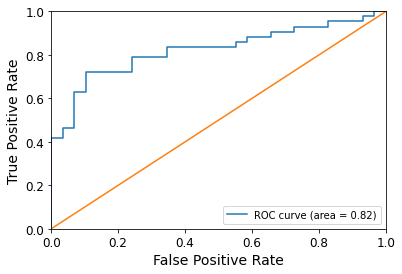

```python
plt.tick_params(axis = 'both', which = 'major',\
 labelsize = 12)
fpr, tpr, _ = metrics.roc_curve(y_down_test,
 Att_class_mod2['mlp']['probs'])
plt.plot(fpr, tpr, label='ROC curve (area = %0.2f)' %\
 Att_class_mod2['mlp']['ROC_AUC_test'])
plt.plot([0, 1], [0, 1])
plt.xlabel('False Positive Rate', fontsize = 14)
plt.ylabel('True Positive Rate', fontsize = 14)
plt.xlim([0.0, 1.0])
plt.ylim([0.0, 1.0])
plt.legend(loc="lower right")
```

To visualise the ROC_AUC metrics, we plot it for the best performing model logistic(in terms of ROC_AUC metric) below:

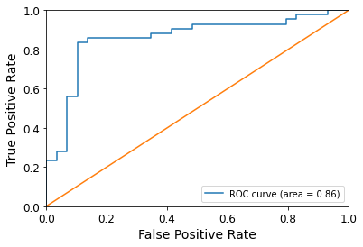

```python
plt.tick_params(axis = 'both', which = 'major',\
 labelsize = 12)
fpr, tpr, _ = metrics.roc_curve(y_down_test,
 Att_class_mod2['logistic']['probs'])
plt.plot(fpr, tpr, label='ROC curve (area = %0.2f)' %\
 Att_class_mod2['logistic']['ROC_AUC_test'])
plt.plot([0, 1], [0, 1])
plt.xlabel('False Positive Rate', fontsize = 14)
plt.ylabel('True Positive Rate', fontsize = 14)
plt.xlim([0.0, 1.0])
plt.ylim([0.0, 1.0])
plt.legend(loc="lower right")
```

**3.2 Comparison of the Model Performance Metric for the Up-Sample and Down-Sample Data**

From the comparison of both model set of metrics, we can see that the model with the **up_sample data** performed better on most of the algorithms than the down sample.

Hence, we will use the upsample data and compute model and carry out the model optimisation and interpretation for our business objectives. First, we observed that the top three performing model are the tree-based models. So we can use them to determine which feaures are important.

We will do this by referencing the **feature*importance*** attributes in the fitted model. These feature improtance is saved along with the name of the feature in separate dataframe for each model.

```python
##Extracting the feature_importance_ attribute of each model
rf_imp_df = pd.DataFrame({ 'name': x_up.columns,\
 'Rf_imp': Att_class_mod['random_forest']['fitted'].\
 feature_importances_})
dt_imp_df = pd.DataFrame({ 'name': x_up.columns,\
 'Dt_imp': Att_class_mod['decision_tree']['fitted'].\
 feature_importances_})
gb_imp_df = pd.DataFrame({ 'name': x_up.columns,\
 'Gb_imp': Att_class_mod['gradient_boosting']['fitted'].\
 feature_importances_})

#We use the Pandas rank function to calculate the rant for the importance measure in each model and save in a dataframe
rf_rank_df = pd.DataFrame({'rf_rank': rf_imp_df['Rf_imp'].\
 rank(method='first', ascending=False).astype(int)})
dt_rank_df = pd.DataFrame({'dt_rank': dt_imp_df['Dt_imp'].\
 rank(method='first', ascending=False).astype(int)})
gb_rank_df = pd.DataFrame({'gb_rank': gb_imp_df['Gb_imp'].\
 rank(method='first', ascending=False).astype(int)})

#Then we join the importance dataframe with itscorresponding rank dataframe , and save it in another dataframe
tree_ranks_df = pd.merge(\
 pd.merge( pd.concat((dt_imp_df, dt_rank_df), axis=1),\
  pd.concat((gb_imp_df, gb_rank_df), axis=1), 'left'),\
  pd.concat((rf_imp_df, rf_rank_df), axis=1), 'left')

#Finally, we calculate the average rank and sort them by this to see the most important features
tree_ranks_df['avg_rank'] = (tree_ranks_df['dt_rank'] + tree_ranks_df['gb_rank'] +  tree_ranks_df['rf_rank'])/3
tree_ranks_df.sort_values(by='avg_rank')
```

|  | name | Dt_imp | dt_rank | Gb_imp | gb_rank | Rf_imp | rf_rank | avg_rank |
| --- | --- | --- | --- | --- | --- | --- | --- | --- |
| 0 | Age | 0.114541 | 2 | 0.069723 | 3 | 0.058422 | 2 | 2.333333 |
| 47 | O_Yes | 0.139260 | 1 | 0.057990 | 5 | 0.042838 | 5 | 3.666667 |
| 9 | MonthlyIncome | 0.036504 | 11 | 0.097038 | 1 | 0.072855 | 1 | 4.333333 |
| 1 | DailyRate | 0.043632 | 8 | 0.059000 | 4 | 0.045399 | 4 | 5.333333 |
| 16 | TotalWorkingYears | 0.074562 | 4 | 0.035880 | 10 | 0.052144 | 3 | 5.666667 |
| 15 | StockOptionLevel | 0.071553 | 5 | 0.070729 | 2 | 0.037809 | 10 | 5.666667 |
| 11 | NumCompaniesWorked | 0.067238 | 6 | 0.041236 | 7 | 0.032075 | 12 | 8.333333 |
| 19 | YearsAtCompany | 0.048275 | 7 | 0.032662 | 13 | 0.038441 | 9 | 9.666667 |
| 4 | EnvironmentSatisfaction | 0.043217 | 9 | 0.038581 | 8 | 0.030138 | 15 | 10.666667 |
| 2 | DistanceFromHome | 0.028844 | 13 | 0.033034 | 12 | 0.038857 | 8 | 11.000000 |
| 7 | JobLevel | 0.080732 | 3 | 0.026724 | 15 | 0.028347 | 16 | 11.333333 |
| 8 | JobSatisfaction | 0.023339 | 15 | 0.037459 | 9 | 0.026649 | 17 | 13.666667 |
| 22 | YearsWithCurrManager | 0.023008 | 16 | 0.031703 | 14 | 0.030852 | 13 | 14.333333 |
| 5 | HourlyRate | 0.034071 | 12 | 0.019888 | 21 | 0.037225 | 11 | 14.666667 |
| 10 | MonthlyRate | 0.016083 | 19 | 0.019507 | 22 | 0.040984 | 7 | 16.000000 |
| 28 | D_Human Resources | 0.038001 | 10 | 0.020560 | 19 | 0.009728 | 27 | 18.666667 |
| 20 | YearsInCurrentRole | 0.012625 | 20 | 0.013846 | 25 | 0.030334 | 14 | 19.666667 |
| 6 | JobInvolvement | 0.000000 | 26 | 0.035073 | 11 | 0.019752 | 23 | 20.000000 |
| 48 | O_No | 0.000000 | 50 | 0.050814 | 6 | 0.041471 | 6 | 20.666667 |
| 43 | J_Human Resources | 0.017699 | 18 | 0.021505 | 18 | 0.011050 | 26 | 20.666667 |
| 12 | PercentSalaryHike | 0.004435 | 25 | 0.020432 | 20 | 0.026594 | 18 | 21.000000 |
| 14 | RelationshipSatisfaction | 0.000000 | 28 | 0.022630 | 17 | 0.022330 | 19 | 21.333333 |
| 21 | YearsSinceLastPromotion | 0.000000 | 30 | 0.022737 | 16 | 0.021331 | 20 | 22.000000 |
| 41 | J_Sales Representative | 0.024931 | 14 | 0.013956 | 24 | 0.008119 | 30 | 22.666667 |
| 17 | TrainingTimesLastYear | 0.009878 | 23 | 0.013161 | 26 | 0.019800 | 22 | 23.666667 |
| 3 | Education | 0.020579 | 17 | 0.006119 | 31 | 0.018664 | 24 | 24.000000 |
| 18 | WorkLifeBalance | 0.000000 | 29 | 0.014446 | 23 | 0.019934 | 21 | 24.333333 |
| 24 | B_Travel_Frequently | 0.000000 | 32 | 0.006651 | 30 | 0.007390 | 31 | 31.000000 |
| 49 | G_Female | 0.011087 | 21 | 0.002525 | 41 | 0.007358 | 32 | 31.333333 |
| 23 | B_Travel_Rarely | 0.000000 | 31 | 0.012877 | 27 | 0.005911 | 41 | 33.000000 |
| 27 | D_Research & Development | 0.000000 | 35 | 0.003049 | 38 | 0.009095 | 28 | 33.666667 |
| 34 | E_Human Resources | 0.000000 | 39 | 0.006690 | 29 | 0.007329 | 33 | 33.666667 |
| 25 | B_Non-Travel | 0.000000 | 33 | 0.003855 | 33 | 0.006556 | 39 | 35.000000 |
| 32 | E_Marketing | 0.000000 | 38 | 0.002841 | 39 | 0.008500 | 29 | 35.333333 |
| 37 | J_Laboratory Technician | 0.000000 | 42 | 0.007363 | 28 | 0.006961 | 37 | 35.666667 |
| 33 | E_Technical Degree | 0.010006 | 22 | 0.000524 | 45 | 0.002360 | 47 | 38.000000 |
| 31 | E_Medical | 0.000000 | 37 | 0.003384 | 35 | 0.004154 | 42 | 38.000000 |
| 13 | PerformanceRating | 0.000000 | 27 | 0.000000 | 47 | 0.003694 | 45 | 39.666667 |
| 30 | E_Other | 0.000000 | 36 | 0.001939 | 43 | 0.006472 | 40 | 39.666667 |
| 35 | J_Sales Executive | 0.000000 | 40 | 0.003139 | 36 | 0.004006 | 43 | 39.666667 |
| 50 | G_Male | 0.000000 | 51 | 0.005295 | 32 | 0.007107 | 36 | 39.666667 |
| 46 | M_Divorced | 0.000000 | 49 | 0.000340 | 46 | 0.016521 | 25 | 40.000000 |
| 42 | J_Research Director | 0.000000 | 46 | 0.002579 | 40 | 0.007183 | 35 | 40.333333 |
| 39 | J_Healthcare Representative | 0.000000 | 44 | 0.003833 | 34 | 0.003813 | 44 | 40.666667 |
| 29 | E_Life Sciences | 0.005898 | 24 | 0.000000 | 49 | 0.001578 | 50 | 41.000000 |
| 44 | M_Single | 0.000000 | 47 | 0.002061 | 42 | 0.007215 | 34 | 41.000000 |
| 40 | J_Manager | 0.000000 | 45 | 0.003113 | 37 | 0.002807 | 46 | 42.666667 |
| 45 | M_Married | 0.000000 | 48 | 0.001506 | 44 | 0.006698 | 38 | 43.333333 |
| 26 | D_Sales | 0.000000 | 34 | 0.000000 | 48 | 0.002309 | 48 | 43.333333 |
| 36 | J_Research Scientist | 0.000000 | 41 | 0.000000 | 50 | 0.001762 | 49 | 46.666667 |
| 38 | J_Manufacturing Director | 0.000000 | 43 | 0.000000 | 51 | 0.001078 | 51 | 48.333333 |

However, we will not rely on the Importance features provided using the Tree-based model because they are biased towards higher-cardinality features(i.e. impurity-based). We would employed a more reliable method called Permutation Feature Importance(PFI) to determine the feature importance. This method is also model-agnostic.

```python
#We computer the permutation importance of all the models using the model dictionary created for the up_sampled data
#PFI shuffles 8 times(n_repeats=8)  and to leverage all processor, n_jobs is set to -1.
for model_name in Att_class_mod.keys():
 fitted_model = Att_class_mod[model_name]['fitted']
 permutation_imp = inspection.permutation_importance(fitted_model, x_up_sc_test, y_up_test, n_jobs=-1,\
 scoring='balanced_accuracy', n_repeats=8, random_state=rand)
 Att_class_mod[model_name]['importances_mean'] = permutation_imp.importances_mean

#The average importance computed for each of the model is then saved in a new dataframe alongside the name of the feature
perm_imp_df = pd.DataFrame({\
 'name': x_up.columns,
 'dt_imp': Att_class_mod['decision_tree']['importances_mean'],\
 'gb_imp': Att_class_mod['gradient_boosting']['importances_mean'],\
 'rf_imp': Att_class_mod['random_forest']['importances_mean'],\
 'log_imp': Att_class_mod['logistic']['importances_mean'],\
 'knn_imp': Att_class_mod['knn']['importances_mean'],\
 'nb_imp': Att_class_mod['naive_bayes']['importances_mean'],\
 'ridge_imp': Att_class_mod['ridge']['importances_mean'],\
 'mlp_imp': Att_class_mod['mlp']['importances_mean']}).reset_index(drop=True)
```

```python
#For the purpose of average,  we compute the average of all the 8 model importance and save in a new column
perm_imp_df['avg_imp'] = (perm_imp_df['dt_imp'] + perm_imp_df['gb_imp'] + perm_imp_df['rf_imp']
+ perm_imp_df['log_imp'] + perm_imp_df['knn_imp'] + perm_imp_df['nb_imp'] + perm_imp_df['ridge_imp'] + perm_imp_df['mlp_imp'] )/8

#The perm_imp_df is sorted using the avg_imp  and save in a new dataframe
perm_imp_sorted_df = perm_imp_df.round(5).sort_values(by='avg_imp', ascending=False)
perm_imp_sorted_df.style. background_gradient(cmap='viridis_r', low=0,
high=0.2, subset=['dt_imp', 'gb_imp', 'rf_imp', 'log_imp', 'knn_imp', 'nb_imp', 'ridge_imp', 'mlp_imp'])
```

|  | name | dt_imp | gb_imp | rf_imp | log_imp | knn_imp | nb_imp | ridge_imp | mlp_imp | avg_imp |
| --- | --- | --- | --- | --- | --- | --- | --- | --- | --- | --- |
| 47 | O_Yes | 0.155050 | 0.023040 | 0.006100 | 0.022810 | 0.013910 | 0.003450 | 0.030340 | 0.029900 | 0.035580 |
| 22 | YearsWithCurrManager | 0.007410 | 0.024970 | 0.002120 | 0.045820 | -0.002480 | -0.001000 | 0.053520 | 0.042590 | 0.021620 |
| 15 | StockOptionLevel | 0.081820 | 0.031170 | 0.012010 | 0.002140 | -0.001260 | -0.003650 | 0.013020 | 0.020880 | 0.019510 |
| 0 | Age | 0.071870 | 0.027790 | 0.005470 | 0.006550 | 0.002790 | -0.000100 | 0.017630 | 0.021100 | 0.019140 |
| 11 | NumCompaniesWorked | 0.060040 | 0.032060 | 0.005130 | 0.012760 | 0.002800 | -0.002590 | 0.021260 | 0.019250 | 0.018840 |
| 48 | O_No | 0.000000 | 0.029490 | 0.000020 | 0.022810 | 0.013910 | 0.003450 | 0.030340 | 0.045050 | 0.018130 |
| 16 | TotalWorkingYears | 0.048640 | 0.007330 | 0.001520 | 0.039930 | -0.002080 | -0.004630 | 0.038090 | 0.004560 | 0.016670 |
| 9 | MonthlyIncome | 0.061730 | 0.053460 | 0.005140 | 0.000000 | -0.005550 | -0.008560 | 0.006430 | 0.011110 | 0.015470 |
| 7 | JobLevel | 0.102180 | 0.004400 | -0.003380 | -0.000740 | -0.006290 | -0.010610 | 0.011620 | 0.020880 | 0.014760 |
| 4 | EnvironmentSatisfaction | 0.020540 | 0.025600 | 0.005070 | 0.006510 | 0.010780 | -0.003380 | 0.014310 | 0.024540 | 0.013000 |
| 8 | JobSatisfaction | 0.019020 | 0.025740 | 0.005810 | 0.008410 | 0.015500 | -0.003700 | 0.015440 | 0.016540 | 0.012850 |
| 20 | YearsInCurrentRole | 0.008610 | 0.012290 | -0.002180 | 0.034500 | 0.002180 | -0.000350 | 0.032950 | 0.010420 | 0.012300 |
| 2 | DistanceFromHome | 0.013030 | 0.016460 | 0.004020 | -0.000740 | 0.005290 | -0.002690 | 0.011210 | 0.026460 | 0.009130 |
| 24 | B_Travel_Frequently | 0.000000 | 0.026640 | 0.001280 | 0.007080 | -0.005360 | -0.006240 | 0.013020 | 0.032460 | 0.008610 |
| 1 | DailyRate | 0.025730 | 0.025650 | 0.003200 | -0.000740 | 0.004210 | -0.001260 | 0.004050 | 0.007810 | 0.008580 |
| 28 | D_Human Resources | 0.044470 | 0.003100 | -0.000210 | -0.002880 | -0.002050 | 0.001020 | 0.003140 | 0.010380 | 0.007120 |
| 6 | JobInvolvement | 0.000000 | 0.010100 | 0.003420 | 0.011630 | 0.005220 | 0.002350 | 0.018110 | 0.005270 | 0.007010 |
| 5 | HourlyRate | 0.022430 | 0.014400 | 0.003510 | -0.004700 | 0.006450 | -0.000210 | 0.005750 | 0.008090 | 0.006970 |
| 40 | J_Manager | 0.000000 | -0.000040 | -0.000210 | 0.015370 | 0.009460 | 0.010230 | 0.011230 | 0.003120 | 0.006140 |
| 12 | PercentSalaryHike | 0.001180 | 0.008320 | 0.001410 | 0.008780 | -0.001140 | -0.002290 | 0.018640 | 0.012210 | 0.005890 |
| 38 | J_Manufacturing Director | 0.000000 | 0.000000 | 0.000000 | 0.011530 | 0.005580 | 0.010010 | 0.012530 | 0.006950 | 0.005830 |
| 35 | J_Sales Executive | 0.000000 | 0.003790 | 0.000000 | 0.009430 | 0.011300 | 0.008640 | 0.009560 | 0.003360 | 0.005760 |
| 19 | YearsAtCompany | 0.005410 | 0.016160 | 0.001280 | 0.007260 | -0.002950 | -0.004100 | 0.020580 | 0.002290 | 0.005740 |
| 44 | M_Single | 0.000000 | 0.000280 | 0.000000 | 0.004210 | 0.003170 | 0.004090 | 0.007940 | 0.026070 | 0.005720 |
| 14 | RelationshipSatisfaction | 0.000000 | 0.012090 | 0.004150 | 0.002530 | -0.002270 | 0.001050 | 0.008250 | 0.016320 | 0.005260 |
| 41 | J_Sales Representative | 0.018540 | 0.008430 | 0.003850 | -0.000920 | 0.004730 | -0.001820 | 0.006770 | 0.001870 | 0.005180 |
| 37 | J_Laboratory Technician | 0.000000 | 0.000870 | 0.002710 | 0.024990 | -0.001190 | -0.007380 | 0.018450 | 0.002530 | 0.005120 |
| 23 | B_Travel_Rarely | 0.000000 | 0.003650 | 0.001070 | 0.010200 | 0.004020 | 0.002250 | 0.004880 | 0.012980 | 0.004880 |
| 36 | J_Research Scientist | 0.000000 | 0.000000 | 0.000000 | 0.028350 | -0.005960 | -0.002580 | 0.017300 | 0.000260 | 0.004670 |
| 43 | J_Human Resources | 0.015460 | 0.007690 | -0.001500 | 0.002570 | -0.001460 | 0.006010 | 0.001630 | 0.003700 | 0.004260 |
| 46 | M_Divorced | 0.000000 | 0.004660 | 0.001770 | 0.004370 | 0.008430 | -0.005510 | 0.010080 | 0.002480 | 0.003290 |
| 39 | J_Healthcare Representative | 0.000000 | 0.000380 | -0.000210 | 0.004510 | 0.003340 | 0.011410 | 0.004640 | 0.001410 | 0.003190 |
| 21 | YearsSinceLastPromotion | 0.000000 | 0.021030 | -0.000430 | -0.002390 | -0.001220 | -0.002500 | 0.006220 | 0.003820 | 0.003060 |
| 30 | E_Other | 0.000000 | 0.002630 | -0.000860 | -0.003450 | -0.001540 | -0.000430 | 0.003660 | 0.023680 | 0.002960 |
| 10 | MonthlyRate | 0.009430 | 0.009470 | 0.002860 | -0.005750 | -0.001160 | -0.001050 | 0.010200 | -0.000770 | 0.002900 |
| 45 | M_Married | 0.000000 | 0.001500 | -0.000860 | -0.003030 | 0.004770 | -0.005260 | 0.011250 | 0.011190 | 0.002450 |
| 34 | E_Human Resources | 0.000000 | 0.004620 | 0.000000 | -0.000620 | -0.002270 | 0.001240 | 0.005410 | 0.004430 | 0.001600 |
| 33 | E_Technical Degree | 0.001770 | -0.000210 | 0.000000 | 0.001220 | 0.000450 | 0.001780 | 0.001010 | 0.006690 | 0.001590 |
| 13 | PerformanceRating | 0.000000 | 0.000000 | 0.000000 | -0.001690 | 0.007020 | -0.003360 | 0.005010 | 0.001860 | 0.001100 |
| 26 | D_Sales | 0.000000 | 0.000000 | 0.000000 | 0.007500 | -0.007670 | -0.000680 | 0.006450 | 0.001930 | 0.000940 |
| 32 | E_Marketing | 0.000000 | -0.000640 | -0.000210 | 0.001420 | -0.006120 | -0.002140 | 0.007180 | 0.007340 | 0.000850 |
| 29 | E_Life Sciences | 0.000640 | 0.000000 | 0.000000 | -0.002820 | 0.007500 | -0.000810 | -0.001970 | 0.003230 | 0.000720 |
| 17 | TrainingTimesLastYear | 0.004810 | 0.005200 | -0.000430 | -0.005750 | 0.001770 | -0.004680 | 0.004320 | 0.000200 | 0.000680 |
| 3 | Education | 0.010830 | 0.002050 | 0.000000 | -0.007080 | -0.007390 | -0.000150 | 0.000660 | 0.005950 | 0.000610 |
| 42 | J_Research Director | 0.000000 | -0.002350 | 0.000000 | 0.002300 | -0.010780 | -0.002140 | 0.003340 | 0.014410 | 0.000600 |
| 25 | B_Non-Travel | 0.000000 | -0.000990 | 0.000000 | -0.000430 | -0.006180 | -0.001070 | 0.001560 | 0.011820 | 0.000590 |
| 49 | G_Female | 0.002140 | 0.001710 | 0.000640 | -0.000320 | -0.008740 | -0.001690 | 0.008120 | 0.002690 | 0.000570 |
| 18 | WorkLifeBalance | 0.000000 | 0.003020 | 0.002250 | -0.003420 | -0.004360 | -0.004090 | 0.000090 | 0.010010 | 0.000430 |
| 50 | G_Male | 0.000000 | 0.000640 | -0.000210 | -0.000320 | -0.008740 | -0.001690 | 0.008120 | 0.004510 | 0.000290 |
| 31 | E_Medical | 0.000000 | -0.000470 | 0.000000 | -0.001390 | -0.001160 | -0.002090 | 0.004680 | 0.001870 | 0.000180 |
| 27 | D_Research & Development | 0.000000 | -0.000210 | 0.000000 | -0.003850 | -0.001220 | 0.000940 | 0.001350 | 0.003850 | 0.000110 |

```python
#Determining the accuracy of all the models on the test data
pd.DataFrame.from_dict(Att_class_mod, 'index')[['Accuracy_test']]
```

[output not shown]

The best performing model in terms of the accuracy on prediction on the test data is still Random Forest.

**3.3 Tuning the Selected Model for Best Performance:** We will employ the Grid Search method to determine the best hyper parameters for our Random Forest model

```python
#Let’s do hyperparameter tuning for Random Forest using GridSearchCV and fit the data.
rf = RandomForestClassifier(random_state=123, n_jobs=-1)

params = {
    'max_depth': [2,3,5,10,20],
    'min_samples_leaf': [5,10,20,50,100,200],
    'n_estimators': [10,25,30,50,100,200]
}

from sklearn.model_selection import GridSearchCV

# Instantiate the grid search model
grid_search = GridSearchCV(estimator=rf, param_grid=params, cv = 4, n_jobs=-1, verbose=1, scoring="accuracy")
```

```python
grid_search.fit(x_up_sc_train, y_up_train)
```

```
Fitting 4 folds for each of 180 candidates, totalling 720 fits
```

```
GridSearchCV(cv=4,
             estimator=RandomForestClassifier(n_jobs=-1, random_state=123),
             n_jobs=-1,
             param_grid={'max_depth': [2, 3, 5, 10, 20],
                         'min_samples_leaf': [5, 10, 20, 50, 100, 200],
                         'n_estimators': [10, 25, 30, 50, 100, 200]},
             scoring='accuracy', verbose=1)
```

```python
#printing the best score
grid_search.best_score_
```

```
0.9026476583172047
```

```python
#printing the best estimator
rf_best = grid_search.best_estimator_
rf_best
```

```
RandomForestClassifier(max_depth=20, min_samples_leaf=5, n_estimators=30,
                       n_jobs=-1, random_state=123)
```

As computed from the GridSearch, the best hyper parameters to use for the model are as follow:

- max_depth=20
- min_samples_leaf=5
- n_estimators=30
- n_jobs=-1

```python
Best_attr_model = ensemble.RandomForestClassifier(max_depth=20, min_samples_leaf=5, n_estimators=30, n_jobs=-1, random_state=rand)
```

```python
best_rf_fitted = Best_attr_model.fit(x_up_sc_train, y_up_train)

y_train_pred1 = best_rf_fitted.predict(x_up_sc_train)
y_test_prob1 = fitted_model.predict_proba(x_up_sc_test)[:,1]
y_test_pred1 = np.where(y_test_prob1 > 0.5, 1, 0)
```

```python
rf_acc_train = metrics.accuracy_score(y_up_train, y_train_pred1)
rf_acc_test = metrics.accuracy_score(y_up_test, y_test_pred1)
rf_recall_train = metrics.recall_score(y_up_train, y_train_pred1)
rf_recall_test = metrics.recall_score(y_up_test, y_test_pred1)
rf_F1 = metrics.f1_score(y_up_test, y_test_pred1)
rf_mcc = metrics.matthews_corrcoef(y_up_test, y_test_pred1)
```

```python
print("Accuracy score - Train: ", rf_acc_train)
print("Accuracy score - Test: ", rf_acc_test)
print("Recall score - Train: ", rf_recall_train)
print("Recall score - Test: ", rf_recall_test)
print("F1 score - Test: ", rf_F1)
print("MCC score - Test: ", rf_mcc)
```

```
Accuracy score - Train:  0.9772850189291509
Accuracy score - Test:  0.8087520259319287
Recall score - Train:  0.9823788546255506
Recall score - Test:  0.8215384615384616
F1 score - Test:  0.8190184049079755
MCC score - Test:  0.6162863435311203
```

**4.0 COnclussion and Recommendations**

Q2: Highlight the top three roles facing attrition Answer: Laborary Technician, Research Scientist, Sales Executive,

Is the length of time with CUrrent manager a factor in deciding attrition? Answer: Yes